# a3_task4_chelsie_mcwhorter

Chelsie McWhorter

10/29/2021

# Assignment 3, Task 4: Naples Reef Purple Urchins

Introduction: Using a data file on sea urchins provided by the [Santa Barbara Coastal LTER](https://sbclter.msi.ucsb.edu/data/catalog/package/?package=knb-lter-sbc.26), I’ll review how removal of kelp in Naples Reef in 2010 influenced purple sea urchins.

Data citation: Reed, D, R. Miller. 2021. SBC LTER: Reef: Long-term experiment: Kelp removal: Urchin size frequency distribution ver 21. Environmental Data Initiative. https://doi.org/10.6073/pasta/fd564dddfe7b77fe9e4bd8417f166057. Accessed 2021-10-28.

## Task 4:

I’ll read in the data and work to create dataframes that allow me to compare the mean size of purple urchins at the Naples Reef location.

#### *Subsection a:* Mean Size comparisons of purple urchins when considering retaining or removal of kelp.

```r
purple_naplesreef <- read_csv(here("data", "urchins.csv")) %>%
  clean_names() %>%
  filter(common_name == "Purple Urchin") %>%
  mutate(date_correct = mdy(date)) %>%
  mutate(year = year(date_correct)) %>%
  filter(site == "NAPL")
```

Now that the above steps have been carried out, I’ll run `unique(purple_naplesreef$site)` and `unique(purple_naplesreef$common_name)` in the console to confirm that the site and type of urchin I’ve attempted to filter did, in fact, work. I’ll also view the dataframe as a whole to ensure it looks how I expect it to look.

#### *Subsection b:* Exploratory Plots of the `purple_naplesreef` data.

**Histogram:**

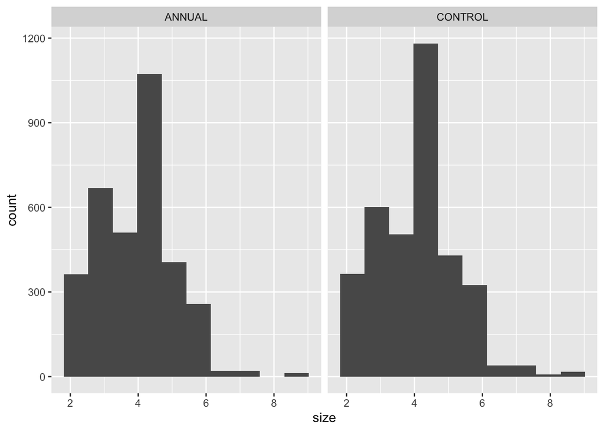

```r
ggplot(data = purple_naplesreef, aes(x =size)) +
  geom_histogram(bins = 10) +
  facet_wrap(~ treatment)
```

**QQ Plot**

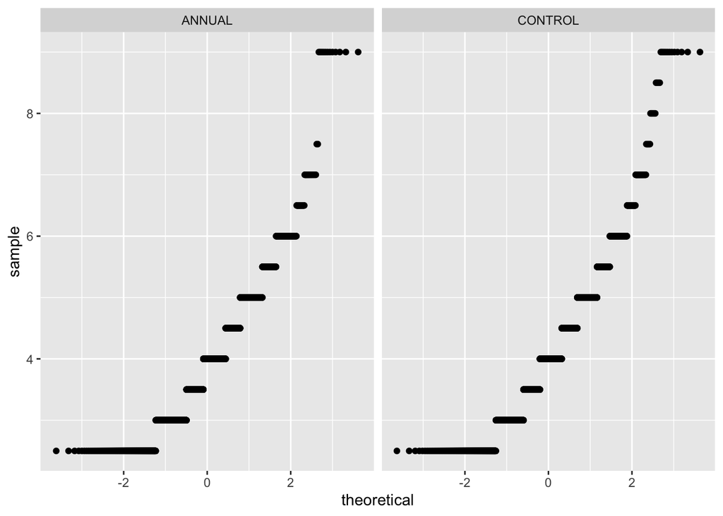

```r
ggplot(data = purple_naplesreef, aes(sample = size)) +
  geom_qq() +
  facet_wrap(~treatment)
```

**Summary:** Overall, I do not see much of a difference between the control and annual groups. The histograms show nearly identical data, with a higher count for the mid-size purple urchins (between 4 -6 cm). The qqplots show a fairly normal distribution (and are nearly identical).

#### *Subsection c:* Descriptive statistics summary table

In this final section, I’ll create a table to display the mean, standard deviation and sample size for each treatment group.

First, I’ll write the code to create the table:

```r
purple_naplesreef_stats <- purple_naplesreef %>%
  group_by(treatment) %>%
  summarize(mean_sizecm = mean(size),
            median_sizecm = median(size),
            sd_size = sd(size),
            samplesize = n())
```

Now that I have the table created, I’ll make it more friendly to look at:

```r
purple_naplesreef_stats %>%
  kable(col.names = c("Treatment",
                      "Mean size (cm)",
                      "Median size (cm)",
                      "Standard Deviation",
                      "Sample Size (n)")) %>%
  kable_styling(position = "center", full_width = FALSE)
```

| Treatment | Mean size (cm) | Median size (cm) | Standard Deviation | Sample Size (n) |
| --- | --- | --- | --- | --- |
| ANNUAL | 3.923747 | 4 | 1.026617 | 3331 |
| CONTROL | 4.044587 | 4 | 1.100244 | 3510 |

### Woo! Assignment 3, task 4 is *finito*!